[GitHub](https://github.com/Janssena/DeepCompartmentModels.jl)[](https://github.com/Janssena/DeepCompartmentModels.jl/blob/main/tutorials/08-end-to-end.qmd)

# Tutorial 8: End-to-End Workflow

*From raw data to a validated mixed-effects DCM on tobramycin*

## Introduction

This tutorial follows a complete pharmacometric modelling workflow:

1. **Exploratory data analysis** — understand the dataset before modelling
2. **Model specification** — choose ODE structure, neural network, and error model
3. **Parameter initialisation and fitting**
4. **Goodness-of-fit diagnostics** — the plots every pharmacometrician needs before trusting a model
5. **Model interrogation** — what did the network learn?

**Dataset:** Tobramycin, an aminoglycoside antibiotic given by IV infusion. Patients receive multiple doses over several days. The dataset contains four covariates: body weight (`WT`), age (`AGE`), sex (`SEX`), and creatinine clearance (`CLCR`), which is the primary driver of aminoglycoside elimination.

## Setup

```julia
using DeepCompartmentModels
using DataFrames, CSV
using Random
using Statistics: mean, std, quantile
using CairoMakie
```

## 1 — Exploratory data analysis

```julia
df = DataFrame(CSV.File(joinpath("/home/runner/work/DeepCompartmentModels.jl/DeepCompartmentModels.jl/tutorials", "../data/tobramycin.csv")))

# Observations: EVID = 0
obs = filter(r -> r.EVID == 0, df)
println("Subjects: $(length(unique(obs.ID)))")
println("Observations: $(nrow(obs))")
println("Obs per subject: min=$(minimum(combine(groupby(obs, :ID), nrow).nrow)), "
        * "max=$(maximum(combine(groupby(obs, :ID), nrow).nrow))")
println("\nCovariates:")
for col in [:WT, :AGE, :CLCR]
    vals = combine(groupby(df, :ID), col => first => col)[!, col]
    println("  $col: $(round(minimum(vals), digits=1)) – $(round(maximum(vals), digits=1))")
end
```

```
Subjects: 97
Observations: 322
Obs per subject: min=1, max=9

Covariates:
  WT: 42.0 – 120.0
  AGE: 16.0 – 85.0
  CLCR: 10.0 – 166.0
```

### Spaghetti plot — raw concentration–time data

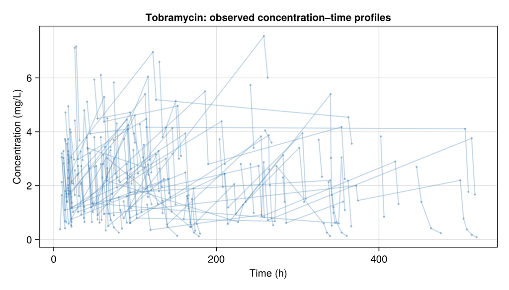

```julia
fig = Figure(size=(700, 400))
ax  = Axis(fig[1,1], xlabel="Time (h)", ylabel="Concentration (mg/L)",
           title="Tobramycin: observed concentration–time profiles")

for group in groupby(obs, :ID)
    t = group.TIME
    y = group.CP
    lines!(ax,  t, y; color=(:steelblue, 0.3))
    scatter!(ax, t, y; color=(:steelblue, 0.5), markersize=4)
end
fig
```

### Covariate distributions

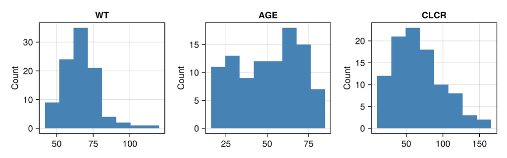

```julia
covs = combine(groupby(df, :ID), :WT => first => :WT, :AGE => first => :AGE,
               :CLCR => first => :CLCR, :SEX => first => :SEX)

fig = Figure(size=(800, 250))
for (i, col) in enumerate([:WT, :AGE, :CLCR])
    ax = Axis(fig[1, i], title=string(col), ylabel="Count")
    hist!(ax, covs[!, col]; bins=8, color=:steelblue)
end
fig
```

## 2 — Load data

```julia
function load_tobramycin(df, ::Type{T} = Float32) where T
    duration = T(40/60)   # 40-minute infusions
    df_group = groupby(df, :ID)
    indvs = Vector{AbstractIndividual}(undef, length(df_group))
    for (i, group) in enumerate(df_group)
        x   = Vector{T}(group[1, [:WT, :AGE, :SEX, :CLCR]])
        obs = group[iszero.(group.EVID), [:TIME, :CP]]
        d   = Matrix{T}(group[group.EVID .== 1, [:TIME, :DOSE]])
        I   = hcat(d, d[:, 2] ./ duration, fill(duration, size(d, 1)))
        cb  = generate_dosing_callback(I, T)
        indvs[i] = Individual(group.ID[1], x, Vector{T}(obs.TIME),
                              Vector{T}(obs.CP), cb, T)
    end
    Population(indvs)
end

population = load_tobramycin(df)
println("Population: $(length(population)) subjects")
```

```
Population: 97 subjects
```

## 3 — Model specification

Tobramycin follows two-compartment kinetics. Creatinine clearance (`CLCR`) is a well-established predictor of CL; weight (`WT`) drives volumes. We let the neural network discover these relationships from data.

```julia
rng = Random.Xoshiro(1)

ann = Lux.Chain(
    Normalize([100f0, 90f0, 1f0, 150f0]),   # WT, AGE, SEX, CLCR
    Lux.Dense(4, 32, tanh),
    Lux.Dense(32, 16, tanh),
    Lux.Dense(16, 4, Lux.softplus),              # CL, V₁, Q, V₂
)

model = DCM(two_comp!, ann, AdditiveError())

obj = VariationalELBO([1, 2]; path_deriv=true)   # random effects on CL and V₁
ps, st = setup(obj, rng, model, population;
    init_omega  = 0.1f0,
    init_sigma  = [0.5f0],
)

println("ps keys: $(keys(ps))")
println("phi keys: $(keys(ps.phi))")
```

```
ps keys: (:theta, :error, :omega, :phi)
phi keys: (:μ, :L)
```

## 4 — Fitting

```julia
opt = Optimisers.Adam(1f-3)
losses = Float32[]

opt_state, ps, st = fit(obj, model, population, opt, ps, st;
    epochs = 1000,
    callback = (epoch, loss) -> begin
        push!(losses, loss)
        epoch % 250 == 0 && println("Epoch $epoch  -ELBO = $(round(loss, digits=2))")
    end,
)
```

[output not shown]

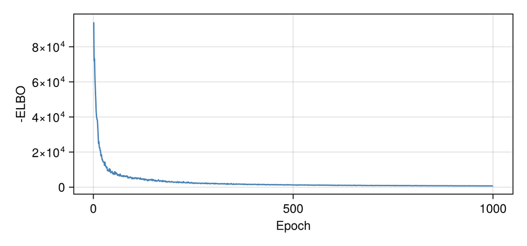

```julia
fig = Figure(size=(600, 280))
ax  = Axis(fig[1,1], xlabel="Epoch", ylabel="-ELBO")
lines!(ax, losses; color=:steelblue)
fig
```

## 5 — Goodness-of-fit diagnostics

All standard GOF plots compare two types of prediction:

- **PRED** — *population* prediction: `predict(model, indv, ps_i, st_i; individual=false)`
- **IPRED** — *individual* prediction: `predict(model, indv, ps_i, st_i; individual=true)`, where `ps_i, st_i = take_batch(ps, st, [i])`

Residuals are **conditional weighted residuals (CWRES)** — scaled by the predicted standard deviation from the error model:

\[\text{CWRES}_{ij} = \frac{y_{ij} - \hat{y}_{ij}}{\sigma(\hat{y}_{ij})}\]

```julia
# Collect all observed and predicted values
σ_error = Lux.softplus(only(ps.error.σ))   # learned additive σ

DV, PRED, IPRED, TIME_all = Float32[], Float32[], Float32[], Float32[]
CWRES_pop, CWRES_ind = Float32[], Float32[]

for (i, indv) in enumerate(population)
    ps_i, st_i = take_batch(ps, st, [i])   # parameters (incl. random effects) of this individual
    y     = get_y(indv)
    t_obs = get_t(indv)
    pred  = predict(model, indv, ps_i, st_i; individual=false)
    ipred = predict(model, indv, ps_i, st_i; individual=true)

    append!(DV,       y)
    append!(PRED,     pred)
    append!(IPRED,    ipred)
    append!(TIME_all, t_obs)
    append!(CWRES_pop, (y .- pred)  ./ σ_error)
    append!(CWRES_ind, (y .- ipred) ./ σ_error)
end
```

### DV vs PRED and DV vs IPRED

The identity line is the target. Systematic curvature or fan-shaped scatter indicates model misspecification or heteroscedastic error.

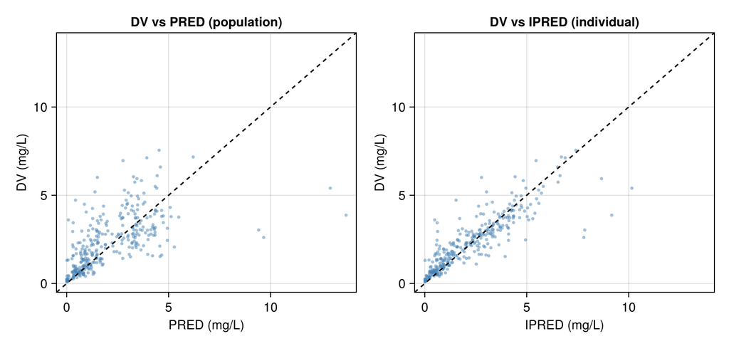

```julia
lims = extrema([DV; PRED; IPRED]) .+ (-0.5f0, 0.5f0)

fig = Figure(size=(800, 380))
ax1 = Axis(fig[1,1], xlabel="PRED (mg/L)", ylabel="DV (mg/L)",
           title="DV vs PRED (population)")
ax2 = Axis(fig[1,2], xlabel="IPRED (mg/L)", ylabel="DV (mg/L)",
           title="DV vs IPRED (individual)")

for (ax, pred_vals) in [(ax1, PRED), (ax2, IPRED)]
    scatter!(ax, pred_vals, DV; color=(:steelblue, 0.5), markersize=5)
    lines!(ax, collect(lims), collect(lims); color=:black, linestyle=:dash)
    xlims!(ax, lims); ylims!(ax, lims)
end
fig
```

### CWRES vs TIME and CWRES vs IPRED

Residuals should be symmetrically scattered around zero with no trends. A trend over time suggests a systematic time-dependent bias; a trend over IPRED suggests the error model is misspecified (e.g. additive when proportional is needed).

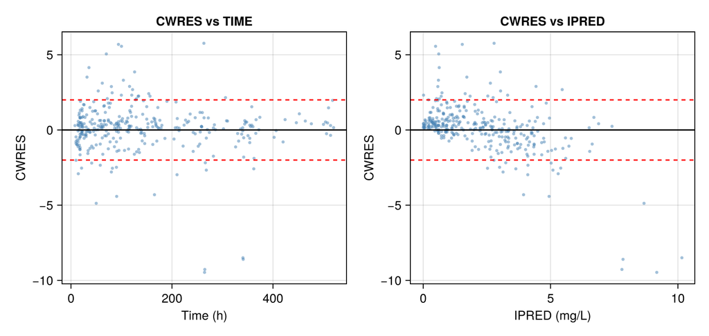

```julia
fig = Figure(size=(800, 380))
ax1 = Axis(fig[1,1], xlabel="Time (h)",       ylabel="CWRES", title="CWRES vs TIME")
ax2 = Axis(fig[1,2], xlabel="IPRED (mg/L)",   ylabel="CWRES", title="CWRES vs IPRED")

for (ax, xvals) in [(ax1, TIME_all), (ax2, IPRED)]
    scatter!(ax, xvals, CWRES_ind; color=(:steelblue, 0.5), markersize=5)
    hlines!(ax, [0f0]; color=:black)
    hlines!(ax, [-2f0, 2f0]; color=:red, linestyle=:dash)
end
fig
```

```julia
# Summary statistics for residuals
println("CWRES (individual) summary:")
println("  Mean: $(round(mean(CWRES_ind), digits=3))")
println("  SD:   $(round(std(CWRES_ind),  digits=3))  (target ≈ 1)")
println("  % within ±2: $(round(100 * mean(abs.(CWRES_ind) .< 2), digits=1))%  (target ≈ 95%)")
```

```
CWRES (individual) summary:
  Mean: 0.103
  SD:   1.688  (target ≈ 1)
  % within ±2: 86.6%  (target ≈ 95%)
```

### Q–Q plot

Tests whether residuals are normally distributed. Points should follow the diagonal. Heavy tails suggest the Gaussian error assumption is violated.

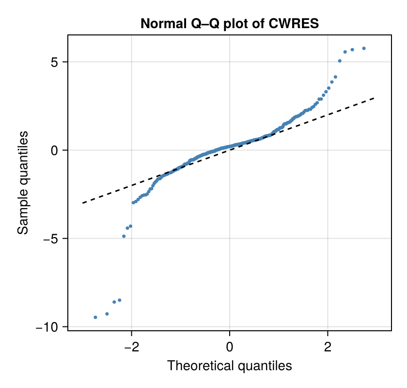

```julia
n   = length(CWRES_ind)
q_theoretical = quantile.(Normal(), (1:n) ./ (n + 1))
q_observed    = sort(CWRES_ind)

fig = Figure(size=(420, 400))
ax  = Axis(fig[1,1], xlabel="Theoretical quantiles", ylabel="Sample quantiles",
           title="Normal Q–Q plot of CWRES")
scatter!(ax, q_theoretical, q_observed; color=:steelblue, markersize=5)
lines!(ax, [-3f0, 3f0], [-3f0, 3f0]; color=:black, linestyle=:dash)
fig
```

### Individual concentration–time fits

The ultimate check: do predictions track the observations subject-by-subject?

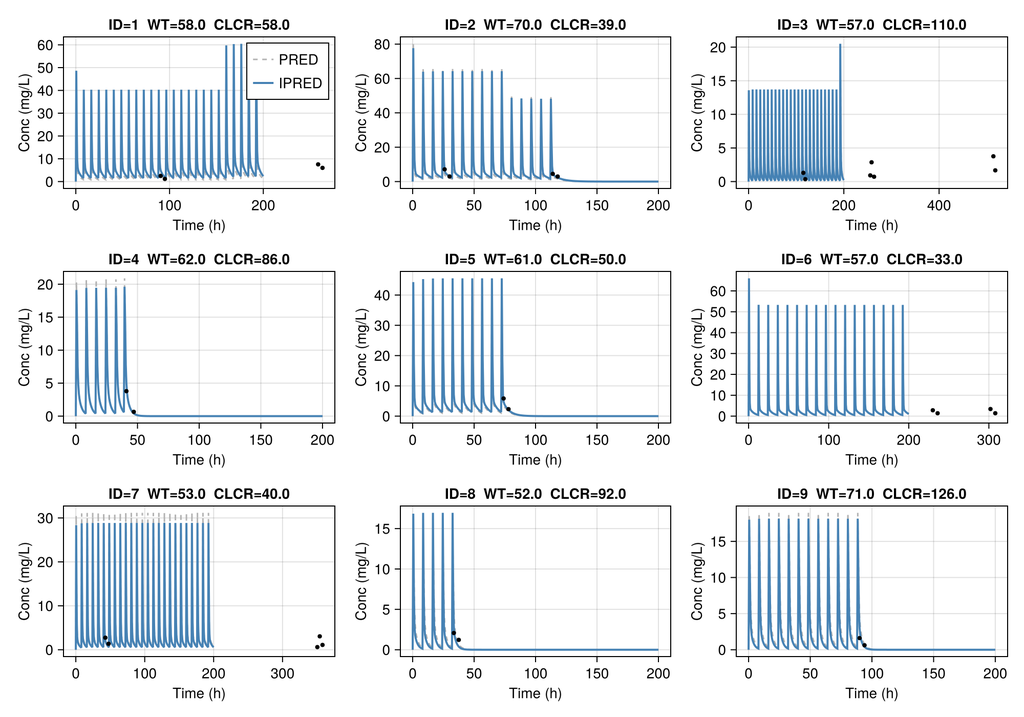

```julia
t_dense = Float32.(0:0.5:200)
fig     = Figure(size=(1000, 700))
ids     = [indv.id for indv in population[1:9]]

for (i, indv) in enumerate(population[1:9])
    row, col = divrem(i - 1, 3)
    ax = Axis(fig[row+1, col+1],
              title="ID=$(indv.id)  WT=$(round(get_x(indv)[1], digits=0))  CLCR=$(round(get_x(indv)[4], digits=0))",
              xlabel="Time (h)", ylabel="Conc (mg/L)")

    ps_i, st_i = take_batch(ps, st, [i])
    pred_pop  = predict(model, indv, ps_i, st_i; individual=false, saveat=t_dense)
    pred_indv = predict(model, indv, ps_i, st_i; individual=true,  saveat=t_dense)

    lines!(ax, t_dense, pred_pop;  color=:gray70,    linestyle=:dash, label="PRED")
    lines!(ax, t_dense, pred_indv; color=:steelblue, linewidth=2,     label="IPRED")
    scatter!(ax, get_t(indv), get_y(indv); color=:black, markersize=6)

    i == 1 && axislegend(ax; position=:rt)
end
fig
```

## 6 — Model interrogation

### What did the network learn about covariates?

We can examine how predicted CL varies with CLCR by sweeping one covariate while holding others at their population median.

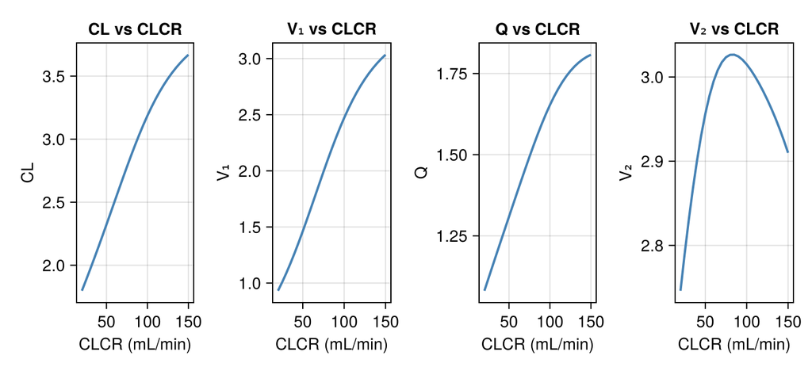

```julia
# Population medians
med = round.(median(get_x(population), dims=2)[:], digits=1)
println("Medians — WT=$(med[1]), AGE=$(med[2]), SEX=$(med[3]), CLCR=$(med[4])")

# Sweep CLCR from 20 to 150 mL/min, hold others at median
clcr_range = Float32.(20:5:150)
x_sweep    = hcat([Float32[med[1], med[2], med[3], c] for c in clcr_range]...)

ζ_sweep, _ = ann(x_sweep, ps.theta, st.theta)   # (4 × n_CLCR)

fig = Figure(size=(700, 320))
for (i, label) in enumerate(["CL", "V₁", "Q", "V₂"])
    ax = Axis(fig[1, i], xlabel="CLCR (mL/min)", ylabel=label,
              title="$label vs CLCR")
    lines!(ax, clcr_range, ζ_sweep[i, :]; color=:steelblue, linewidth=2)
end
fig
```

### Learned residual error

```julia
println("Learned σ (additive): $(round(Lux.softplus(only(ps.error.σ)), digits=4)) mg/L")
println("Omega (random effects prior variance):")
println(round.(ps.omega, digits=4))
```

```
Learned σ (additive): 0.5598 mg/L
Omega (random effects prior variance):
Float32[0.1 0.0; 0.0 0.1]
```

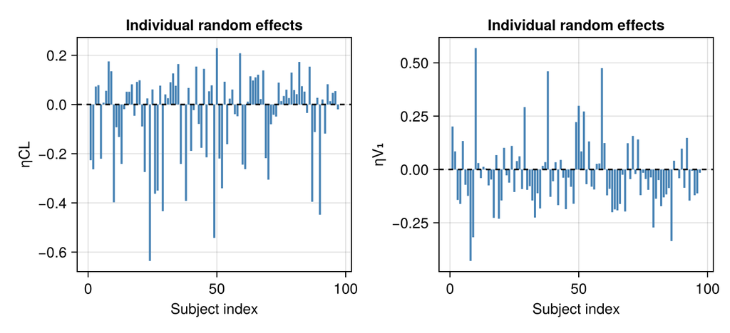

```julia
η = hcat(ps.phi.μ...)   # 2 × n_subjects

fig = Figure(size=(700, 320))
for (i, label) in enumerate(["ηCL", "ηV₁"])
    ax = Axis(fig[1, i], xlabel="Subject index", ylabel=label,
              title="Individual random effects")
    barplot!(ax, 1:length(population), η[i, :]; color=:steelblue)
    hlines!(ax, [0f0]; color=:black, linestyle=:dash)
end
fig
```

## Summary

A complete validation workflow in DeepCompartmentModels.jl requires:

| Plot | What to look for |
| --- | --- |
| DV vs PRED | Points on the identity line; no systematic bias |
| DV vs IPRED | Tighter scatter than vs PRED; similar pattern |
| CWRES vs TIME | No trend; ~95% within ±2 |
| CWRES vs IPRED | Homoscedastic scatter around zero |
| Q–Q plot | Points follow the diagonal; no heavy tails |
| Individual fits | Predictions track observations for each subject |